# Homework #2

Craig Beuerlein

September 16, 2019

## Import Dataset

*R Code to import the dataset “espresso1.csv” from a local directory on the computer*

```r
espresso <- read.csv("espresso1.csv")
glimpse(espresso)
```

```
## Observations: 27
## Variables: 2
## $ foamIndx <dbl> 36.64, 39.65, 37.74, 35.96, 38.52, 21.02, 24.81, 34.18,…
## $ method   <fct> BM, BM, BM, BM, BM, BM, BM, BM, BM, HIP, HIP, HIP, HIP,…
```

## Question 1

**In words, describe a procedure for how the experimenter should have determined which to use on any particular group of coffee beans.**

*An experimenter should have used a randomization procedure to assign experimental units to treatments (such as a CDR in R), which would make the effects of lurking variables distributed across all conditions in the experiment.*

## Question 2

**Generate a table of meaningful summary statistics by brewing method. Comment on the result.**

*R Code to generate meaningful summary statistics by brewing method*

```r
espresso %>%
  group_by(method) %>%
  summarize(Mean=mean(foamIndx),
            SD=sd(foamIndx),
            Median=median(foamIndx),
            Min=min(foamIndx),
            N=n()) %>%
  kable()
```

| method | Mean | SD | Median | Min | N |
| --- | --- | --- | --- | --- | --- |
| BM | 32.4 | 7.300060 | 35.96 | 21.02 | 9 |
| HIP | 61.3 | 10.100604 | 62.53 | 46.68 | 9 |
| IT | 39.7 | 7.700768 | 37.12 | 32.68 | 9 |

**The data summary shows that the Bar Machine Method and the Espresso System method have similar mean values, median values, and standard deviation values. However, the Hyper-Espresso Method are significantly larger compared to the other values in the data set.**

## Question 3

**Plot the distributions of foam index by brewing method. Comment on what you see, including comment on average and variation in foam index**

*R Code to plot the distributions of foam index by the brewing method*

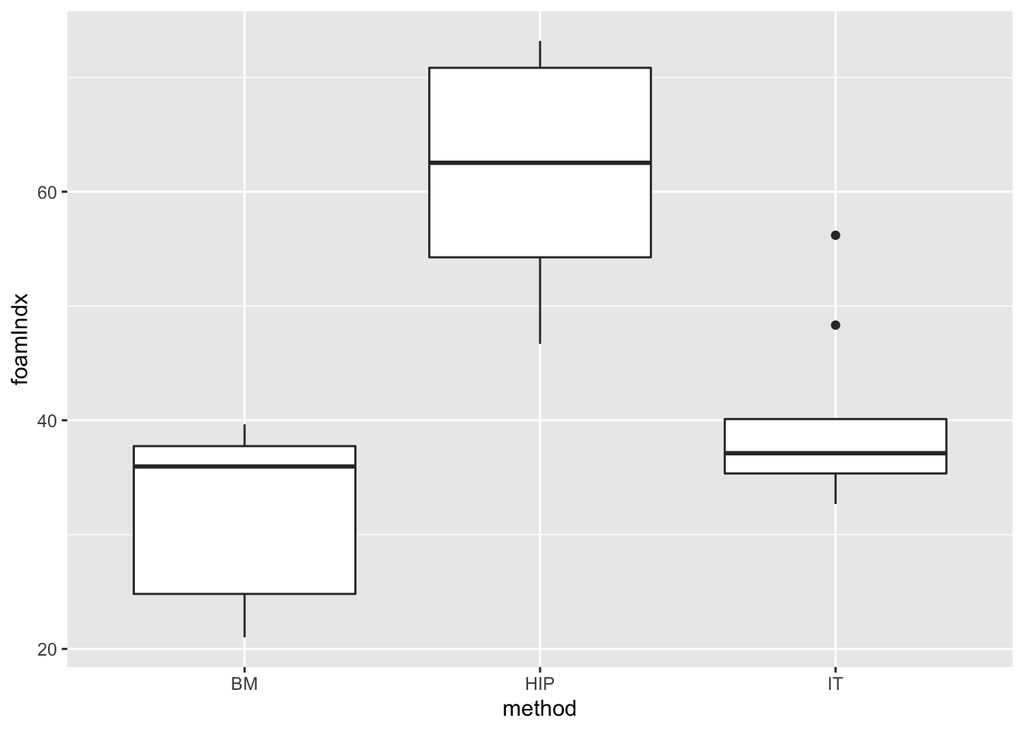

```r
ggplot(espresso) + geom_boxplot(aes(x=method, y=foamIndx))
```

**The Box Plot produced above show that the Bar Machine Method and the Espresso System method have similar averages, but the Hyper-Espresso Method has the highest foam index value and variation. The Espresso System has two outliers that are higher than the rest of the values in the dataset.**

## Question 4

**Check the model assumptions for the ANOVA testing if there is any difference in true mean foam index between the three brewing methods.**

*R Code to conduct an ANOVA test*

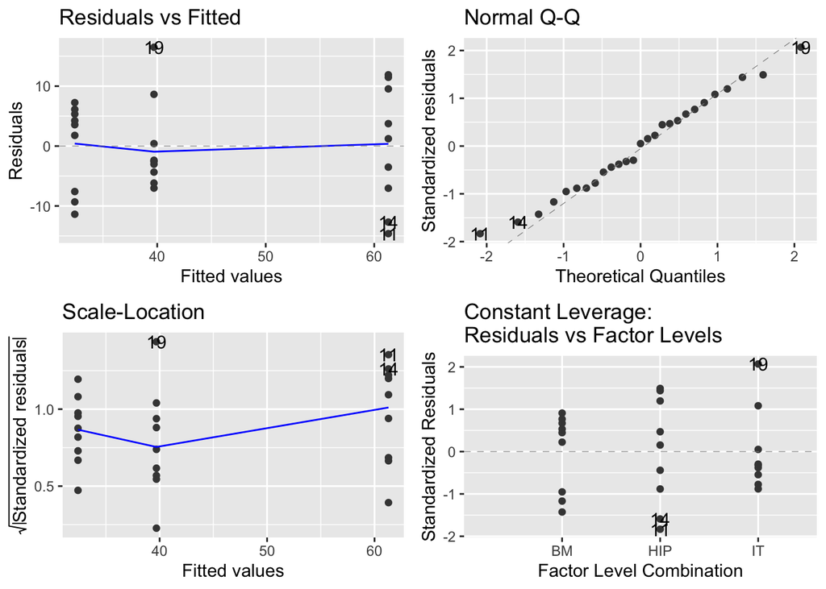

```r
espresso.anova <- aov(foamIndx ~ method, data=espresso)
library(ggfortify)
autoplot(espresso.anova)
```

**There are no concerns with the plots of data. The Residuals vs. Fitted and Scale-Location plots are fairly horizontal and there is not any systematic patterns in the plotted points in regards to Constant Variance. The points in the Normal Q-Q plot follow a 45-degree line in regards to Normality. All test were independent because the different methods were randomized.**

## Question 5

**Provide the ANOVA output. Report your F-statistic value, both numerator and denominator degrees of freedom, the p-value, and the conclusion in problem context.**

*R Code to generate output from the previous ANOVA test*

```r
summary(espresso.anova)
```

```
##             Df Sum Sq Mean Sq F value  Pr(>F)
## method       2   4065  2032.6   28.41 4.7e-07 ***
## Residuals   24   1717    71.5
## ---
## Signif. codes:  0 '***' 0.001 '**' 0.01 '*' 0.05 '.' 0.1 ' ' 1
```

**The F-Value is reported as 28.41 on degrees of freedom 2 and 24. This is significantly higher than the value of 1 because the p-value is reported as 4.7e-07. Therefore there is evidence to suggest the different brewing methods influence the foam index. However, the p-value is only accurate because we have assumed that the underlying assumptions of the ANOVA were met.**

## Qeustion 6

**Perform Tukey-adjusted multiple comparisons (only if necessary!) and report the results in context.**

*R Code to perform a Tukey-adjusted multiple comparison test*

```r
espresso.mc <- emmeans(espresso.anova, "method")
contrast(espresso.mc, "pairwise")
```

```
##  contrast estimate   SE df t.ratio p.value
##  BM - HIP    -28.9 3.99 24 -7.248  <.0001
##  BM - IT      -7.3 3.99 24 -1.831  0.1811
##  HIP - IT     21.6 3.99 24  5.417  <.0001
##
## P value adjustment: tukey method for comparing a family of 3 estimates
```

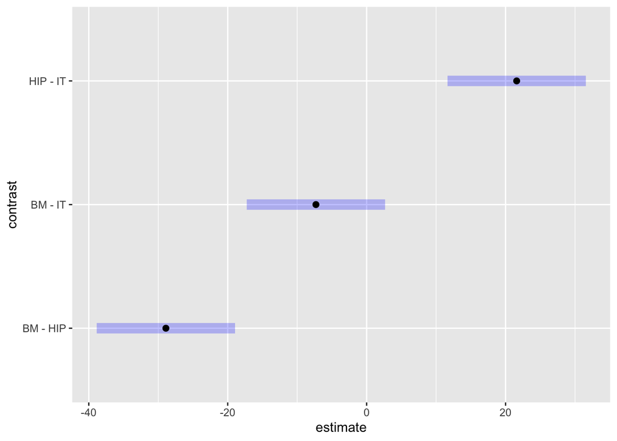

```r
plot(contrast(espresso.mc, "pairwise"))
```

**According to the estimated values reported, the Hyper-Espresso Method produces significantly more foam than any other method. We know this because in comparisons with the Hyper-Espresso Method, a larger number is produced (-28.9 & 21.6).**